# S2 MET Marker Stability Analysis

This notebook will look at marker effect stability from marker effect estimates in each environment

## Introduction

Load packages and set directories

```r
library(tidyverse)
library(stringr)
library(readxl)
library(GenomicRanges)
library(qvalue)
library(lme4qtl)
library(patchwork)
library(neyhart)
# Project and other directories
source("C:/Users/Jeff/Google Drive/Barley Lab/Projects/S2MET_Mapping/source.R")
# Load the stability results
load(file.path(result_dir, "S2MET_pheno_mean_fw_results.RData"))
# # List the files containing marker effect by environment estimates
# mxe_files <- list.files(result_dir, pattern = "marker_by_env", full.names = TRUE)
#
# # Iterate over files and save in a list
# mxe_list <- list()
# for (file in mxe_files) {
#   load(file)
#   trait <- str_extract(string = file, "[A-Za-z]*.RData") %>% str_replace(pattern = ".RData", "")
#
#   mxe_list[[trait]] <- marker_score_out
# }
# Load the mxe results
load(file.path(result_dir, "S2MET_marker_ranef_by_env.RData"))
# Get the marker information
snp_info <- S2TP_imputed_multi_genos_hmp %>%
  select(marker = rs, chrom, pos, cM_pos)
# Filter the BLUEs to use
S2_MET_BLUEs_use <- S2_MET_BLUEs %>%
  filter(line_name %in% c(tp_geno)) %>%
  droplevels()
M <- S2TP_imputed_multi_genos_mat[tp_geno,]
```

## Results

Manage the mxe data and convert to a tidy data.frame

```r
# # Tidy up
# marker_by_environment <- mxe_list %>%
#   map(~map_df(., ~list(., names(.)) %>% pmap_df(~mutate(.x, marker = .y)))) %>%
#   list(., names(.)) %>%
#   pmap_df(~mutate(.x, trait = .y)) %>%
#   as_data_frame() %>%
#   select(trait, marker, names(.))
#
# # Rename
# mxe_df <- marker_by_environment %>%
#   mutate(environment = str_extract(term, "[A-Z]{3}[0-9]{2}")) %>%
#   select(trait, marker, environment, estimate)
mxe_df <- marker_by_env %>%
  unnest(marker_effect) %>%
  ungroup()
# Combine with the environmental mean
mxe_df1 <- mxe_df %>%
  left_join(., distinct(S2_MET_pheno_mean_fw, trait, environment, h),
            by = c("environment", "trait"))
```

```
Column `environment` joining factor and character vector, coercing into character vector
```

```r
# Calculate the marker effect stability
marker_effect_stab <- mxe_df1 %>%
  group_by(trait, marker) %>%
  do({
    df <- .
    # Fit the model
    fit <- lm(effect ~ h, df)
    data_frame(b = coef(fit)[2],
               b_std_error = summary(fit)$coefficients[2,"Std. Error"],
               delta = mean(resid(fit)^2),
               df = df.residual(fit),
               fit = list(fit)) })
```

Plot the distribution of stability estimates

```r
## Transform
S2_MET_marker_mean_fw_trans <- S2_MET_marker_mean_fw %>%
  distinct(marker, chrom, pos, trait, b, delta) %>%
  mutate(log_delta = log(delta), b = b + 1)
```

[output not shown]

First group markers into those that are highly stable, highly sensitive, or neither using empirical thresholds

```r
# Tidy up
S2_MET_marker_mean_fw_tidy <- S2_MET_marker_mean_fw_trans %>%
  select(-delta) %>%
  gather(coef, estimate, -marker:-trait)

# What should be the cutoff level?
alpha <- 0.05
# For each trait, calculate empirical thresholds for significance
S2_MET_marker_eff_pheno_fw_sig <- S2_MET_marker_mean_fw_tidy %>%
  filter(coef == "b") %>%
  group_by(trait) %>%
  # mutate(estimate = scale(estimate)) %>%
  mutate(lower_perc = quantile(estimate, alpha / 2),
         upper_perc = quantile(estimate, 1 - (alpha / 2))) %>%
  ungroup() %>%
  mutate(significance = case_when(estimate >= upper_perc ~ "sensitive",
                                  estimate <= lower_perc ~ "stable",
                                  TRUE ~ "average"),
         marker_type = if_else(str_detect(marker, "^S"), "GBS", "BOPA"))
# Calculate a table of GBS markers and sensitive/stable/notsignificant
mar_stab_table <- S2_MET_marker_eff_pheno_fw_sig %>%
  group_by(trait, marker_type, significance) %>%
  summarize(n = n()) %>%
  mutate(prop = n / sum(n))
mar_stab_table %>%
  select(-n) %>%
  spread(significance, prop)
```

|  | trait | marker_type | average | sensitive | stable |
| --- | --- | --- | --- | --- | --- |
| 1 | GrainYield | BOPA | 0.9108461 | 0.04372516 | 0.04542873 |
| 2 | GrainYield | GBS | 0.9591647 | 0.02061719 | 0.02021814 |
| 3 | HeadingDate | BOPA | 0.9148211 | 0.04202158 | 0.04315730 |
| 4 | HeadingDate | GBS | 0.9582336 | 0.02101623 | 0.02075020 |
| 5 | PlantHeight | BOPA | 0.9091425 | 0.04315730 | 0.04770017 |
| 6 | PlantHeight | GBS | 0.9594307 | 0.02075020 | 0.01981910 |

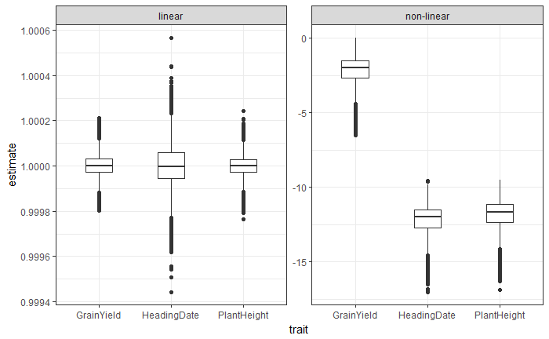

```r
# Plot the distributions of marker effect stabilities and show the empirical threholds
g_b_dist <- S2_MET_marker_eff_pheno_fw_sig %>%
  ggplot(aes(x = estimate, fill = "red")) +
  geom_density() +
  geom_vline(aes(xintercept = upper_perc)) +
  geom_vline(aes(xintercept = lower_perc)) +
  facet_wrap(~ trait, ncol = 1, scales = "free_x") +
  scale_fill_discrete(guide = FALSE) +
  theme_bw()
# Boxplots
S2_MET_marker_mean_fw_tidy %>%
  mutate(coef = if_else(coef == "b", "linear", "non-linear")) %>%
  ggplot(aes(x = trait, y = estimate)) +
  geom_boxplot() +
  facet_wrap(~ coef, scales = "free_y") +
  theme_bw()
```

```r
# Calculate the mean stability per group
S2_MET_marker_eff_pheno_fw_sig %>%
  group_by(trait, significance) %>%
  summarize(mean = mean(estimate)) %>%
  spread(significance, mean)
```

|  | trait | average | sensitive | stable |
| --- | --- | --- | --- | --- |
| 1 | GrainYield | 1.0000014 | 1.000130 | 0.9998678 |
| 2 | HeadingDate | 1.0000013 | 1.000264 | 0.9997394 |
| 3 | PlantHeight | 0.9999998 | 1.000123 | 0.9998776 |

Plot the stability estimates across the genome with the empirical threshold

```r
# Color theme
colors <- c("black", umn_palette(n = 4)[-c(1:2)]) %>%
  set_names(c("average", "sensitive", "stable"))
g_mar_stab <- S2_MET_marker_eff_pheno_fw_sig %>%
  ggplot(aes(x = pos / 1000000, y = estimate, col = significance)) +
  geom_point() +
  geom_hline(aes(yintercept = lower_perc), lty = 2) +
  geom_hline(aes(yintercept = upper_perc), lty = 2) +
  scale_color_manual(values = colors, name = "Marker Group") +
  ylab("Linear Stability Estimate") +
  xlab("Position (Mbp)") +
  facet_grid(trait ~ chrom, scales = "free", space = "free_x", switch = "x") +
  theme_manhattan()
# Save
save_file <- file.path(fig_dir, "marker_stability_genome.jpg")
ggsave(filename = save_file, plot = g_mar_stab, height = 6.5, width = 9, dpi = 500)
```

Determine the proportion of GxE variance ($V_{GE}$) that is explained by sensitive/stable markers vs not signficant markers

The mixed-model looks like:

$$y_{ij} = \mu + g_i + t_j + (g_st)_{ij} + (g_{ns}t)_{ij} + \epsilon_{ij},$$

where $g_i \sim N(0, \mathbf{K}\sigma^2_g)$, $(g_st)_{ij} \sim N(0, \mathbf{K_s}\sigma^2_{g_st})$, and $(g_{ns}t)_{ij} \sim N(0, \mathbf{K_{ns}}\sigma^2_{g_{ns}t})$. $\mathbf{K}$ is the kinship matrix calculated using all markers, $\mathbf{K_s}$ is the kinship matrix calculated using only stable/sensitive markers, and $\mathbf{K_{ns}}$ is the kinship matrix calculated using only non-signficiant markers

```r
# Load the results
load(file.path(result_dir, "S2MET_pheno_mar_fw_varcomp_GrainYield.RData"))

var_comp_prop <- var_comp_out$GrainYield %>%
  bind_rows() %>%
  by_row(sum, .collate = "cols", .to = "tot_var") %>%
  mutate_at(vars(-tot_var), funs(prop = . / tot_var))

# Test if the observations come from the same distribution
var_comp_prop %>%
  summarize(ks_test = ks.test(x = gt_s_prop, gt_ns_prop)$p.value)

# Plot density plots for each type of marker
var_comp_prop %>%
  select(gt_s_prop, gt_ns_prop) %>%
  gather(term, prop) %>%
  ggplot(aes(x = prop, fill = term)) +
  geom_density(alpha = 0.75) +
  theme_bw()
```

[output not shown]

#### Gene Annotation

Look at gene annotation with relation to the different groups of SNPs. Determine the proportion of SNPs in genes, gene-proximal, or intergenic Perhaps look at other annotations such as exons or transcripts, etc.

```r
## Load the barley annotation
ann_dir <- "C:/Users/Jeff/Google Drive/Barley Lab/Projects/Genomics/Annotation"
load(file.path(ann_dir, "barley_genomic_ranges.RData"))

# Conver the SNPs in this experiment to a GRanges object
snp_info <- S2TP_imputed_multi_genos_hmp %>%
  select(rs:cM_pos) %>%
  separate(alleles, c("ref", "alt"), "/") %>%
  mutate(chrom = str_c("chr", chrom, "H"))

snp_info_grange <- GRanges(seqnames = snp_info$chrom,
                           ranges = IRanges(snp_info$pos, snp_info$pos),
                           ref = snp_info$ref, alt = snp_info$alt,
                           cM_pos = snp_info$cM_pos, rs = snp_info$rs)


# Find the distance to the nearest gene for each SNP
# Convert to a data.frame and add the SNP info
snp_info_distance_to_gene <- distanceToNearest(x = snp_info_grange, subject = barley_grange_list$genes) %>%
  as.data.frame() %>%
  bind_cols(snp_info, .) %>%
  mutate(gene_id = barley_grange_list$genes[subjectHits]$gene_id) %>% # Add the gene id
  select(-queryHits, -subjectHits)

# Assign a cutoff for proximal
proximity_cutoff <- 10000

## Assign genic, proximal, or non-genic
snp_info_distance_to_gene_ann <- snp_info_distance_to_gene %>%
  mutate(class = case_when(distance == 0 ~ "genic",
                           between(distance, 0, proximity_cutoff) ~ "proximal",
                           distance > proximity_cutoff ~ "non-genic",
                           TRUE ~ as.character(NA)),
         class = parse_factor(class, levels = c("genic", "proximal", "non-genic")),
         marker_type = if_else(str_detect(rs, "^[1-2]{2}"), "BOPA", "GBS")) %>%
  dplyr::rename(marker = rs)

# Find the proportion of SNPs that are in each group. This forms the null proportion
null_snp_prop <- snp_info_distance_to_gene_ann %>%
  group_by(class) %>%
  summarize(nSNP = n()) %>%
  mutate(prop = nSNP / sum(nSNP))

# Curiosity - is there a difference between GBS and BOPA snps?
# Yes - vast majority of BOPA markers are genic - derived from ESTs - this makes sense

# Now use the marker stability estimates to group SNPs
snp_info_distance_to_gene_ann1 <- snp_info_distance_to_gene_ann %>%
  full_join(., select(S2_MET_marker_eff_pheno_fw_sig, marker, trait, significance),
            by = "marker")

# Group by the marker stability classes and calculate proportions
# Then add the null proportion
marker_stability_snp_prop <- snp_info_distance_to_gene_ann1 %>%
  group_by(trait, significance, class) %>%
  summarize(nSNP = n()) %>%
  mutate(prop = nSNP / sum(nSNP),
         significance_SNP = sum(nSNP)) %>%
  left_join(., select(null_snp_prop, class, null_prop = prop), by = "class")


# Table
marker_stability_snp_prop %>%
  select(-nSNP, -null_prop) %>%
  spread(class, prop)

## Perform an binomial exact test
## H0: the proportion of SNPs in each significance group in each class is
## not different than the proportion across all SNPs
marker_stability_snp_prop_test <- marker_stability_snp_prop %>%
  group_by(trait, significance, class) %>%
  mutate(binom_test = list({binom.test(x = nSNP, n = significance_SNP, p = null_prop)})) %>%
  ungroup() %>%
  mutate(p_value = map_dbl(binom_test, "p.value"),
         p_ann = case_when(p_value <= 0.01 ~ "***",
                           p_value <= 0.05 ~ "**",
                           p_value <= 0.10 ~ "*",
                           TRUE ~ ""))


# Plot
g_snp_ann_prop <- marker_stability_snp_prop_test %>%
  select(trait, class, prop = null_prop) %>%
  distinct() %>%
  mutate(significance = "null") %>%
  bind_rows(marker_stability_snp_prop_test, .) %>%
  mutate(significance = parse_factor(significance, levels = c("null", "average", "sensitive", "stable"))) %>%
  ggplot(aes(x = class, y = prop, fill = significance,  group = significance)) +
  geom_col(position = "dodge") +
  geom_text(aes(label = p_ann), position = position_dodge(0.9), hjust = -1, vjust = 0.5, angle = 90) +
  scale_fill_manual(values = rev(umn_palette(n = 6)[-c(1:2)])) + # Add custom colors
  facet_grid(~ trait) +
  theme_bw()

save_file <- file.path(fig_dir, "marker_stability_gene_annotation.jpg")
ggsave(filename = save_file, plot = g_snp_ann_prop, height = 5, width = 8)
```

#### Overlap with Stability and Mean Loci

Load the GWAS results for genotypic mean and phenotypic stability and see if the markers with the highest plasticity/stability measure overlap

```r
# Write the table
save_file <- file.path(fig_dir, "marker_stability_outliers.csv")
write_csv(x = marker_stab_outliers_toprint, path = save_file)
```

```
cannot open file 'C:/Users/Jeff/Google Drive/Barley Lab/Projects/S2MET_Mapping///Figures/marker_stability_outliers.csv': Permission deniedError in open.connection(path, "wb") : cannot open the connection
```

Further analysis

```r
# Create Grange objects
marker_stab_outliers_grange <- marker_stab_outliers %>%
  group_by(trait, significance) %>%
  do(queryGrange = makeGRangesFromDataFrame(df = ., keep.extra.columns = TRUE, start.field = "pos", end.field = "pos"))

# Create granges with the signficant GWAS SNPs
sig_markers_grange <- sig_markers_grange_df %>%
  group_by(trait, coef) %>%
  do(subjectGrange = GRanges(.))

# Intersect with the multi-locus mixed model results
grange_combined <- inner_join(x = sig_markers_grange, y = marker_stab_outliers_grange) %>%
  ungroup()


## Group by row, and find any overlap between the stable/plastic markers and QTL for the
## specific trait/coef
grange_combined_overlap <- grange_combined %>%
  rowwise() %>%
  do({
    df <- .

    # Calculate the distance from each of the markers to the significant loci (on the
    # appropriate chromosome )
    hits <- distanceToNearest(x = df$queryGrange, subject = df$subjectGrange)

    # Filter for overlap and get the granges for the subject and query
    hits_grange <- hits %>%
      as_data_frame() %>%
      filter(distance == 0) %>%
      mutate(queryGrange = map(queryHits, ~df$queryGrange[.]),
             subjectGrange = map(subjectHits, ~df$subjectGrange[.]))

    # Combine with the original df
    hits_grange %>%
      mutate(trait = df$trait, coef = df$coef, significance = df$significance) %>%
      select(trait:significance, distance, queryGrange, subjectGrange)

  })

# Convert the Granges to df
grange_combined_overlap_df <- grange_combined_overlap %>%
  ungroup() %>%
  mutate_at(vars(contains("Grange")), funs(map(., as.data.frame)))



# Find the proprotion of markers that overlapped for each trait
grange_combined_overlap_df %>%
  mutate(query_markers = map_chr(queryGrange, "marker")) %>%
  group_by(trait) %>%
  summarize(prop_query_markers = n_distinct(query_markers) / (7 * 2))


# Convert to a more readable DF
grange_combined_overlap_df1 <- grange_combined_overlap_df %>%
  unnest() %>%
  select(trait, coef, significance, chrom = seqnames, query_pos = start,
         query_marker = marker, query_estimate = estimate,
         query_marker_type = marker_type, subject_start = start1, subject_end = end1,
         subject_marker = marker1, alpha, subject_pos = snp_pos)

# Calculate the distance and LD between the SNPs
grange_combined_overlap_summ <- grange_combined_overlap_df1 %>%
  rowwise() %>%
  do({
    df <- .

    distance <- abs(df$query_pos - df$subject_pos)
    LD <- (cor(M[,c(df$query_marker, df$subject_marker)])^2)[1,2]

    df %>%
      as.data.frame() %>%
      select(trait:chrom) %>%
      mutate(distance = distance, LD = LD)

  })
```